# A1.1 663794

## Actividad 1.1

Esta actividad consiste en elaborar un reporte técnico de aprendizaje estadístico-automático a partir de un conjunto de datos sobre niveles de obesidad en población de Colombia, Perú y México. El objetivo es que analices el conjunto de datos de manera integral, comenzando con una exploración inicial, reflexiones críticamente sobre el diseño del estudio, definas una variable de interés para inferencia, y realices un análisis gráfico enfocado en una subpoblación específica

### Introducción

El problema de la obesidad se ha consolidado como uno de los principales problemas de salud publica a nivel mundial, impactando principalmente a paises latinoamericanos. Su origen es multifactorial y esta estrechamente relacionado con habitos alimenticios, su atividad fisica, caracteristicas demograficas y mas factores relacionados a su estilo de vida.

En este contexto, la presente actividad se centra en el análisis de un conjunto de datos recopilado por investigadores de la Universidad de la Costa, que incluye información de individuos provenientes de Colombia, Perú y México. Dicho conjunto de datos contiene variables demográficas, de hábitos y de salud, así como una variable categórica que describe el nivel de obesidad calculado a partir del índice de masa corporal. A través de técnicas de análisis exploratorio y de inferencia estadística, se busca identificar patrones, relaciones y comportamientos relevantes dentro de la información.

El objetivo de este reporte es documentar de manera clara y estructurada el proceso de análisis realizado, presentando la metodología empleada, los principales resultados obtenidos y las conclusiones derivadas.

### Metodologia

Para realizar el análisis, se utilizó Python como lenguaje de programación, apoyándose en la biblioteca pandas para la manipulación y análisis de datos, matplotlib y seaborn para la generación de visualizaciones, y scikit-learn como apoyo potencial para técnicas de inferencia o modelado. Esta combinación permitió realizar un análisis eficiente del conjunto de datos y obtener resultados claros para su posterior interpretación.

A continuación, se presenta el código utilizado para la carga y exploración inicial del conjunto de datos, cuyo objetivo es comprender la estructura, dimensiones y tipos de variables disponibles, así como obtener un primer acercamiento estadístico a la información:

```python
import pandas as pd
import matplotlib.pyplot as plt
import seaborn as sns

# Cargar el conjunto de datos
data = pd.read_csv("A1.1 Obesidad.csv")

# Exploración inicial del conjunto de datos
print(data.head())
```

```
     Sexo  Edad  Estatura  Peso FamiliarConSobrepeso ComeMuchasCalorias  \
0  Female  21.0      1.62  64.0                  yes                 no
1  Female  21.0      1.52  56.0                  yes                 no
2    Male  23.0      1.80  77.0                  yes                 no
3    Male  27.0      1.80  87.0                   no                 no
4    Male  22.0      1.78  89.8                   no                 no

   ComeVegetales Fumador  ConsumoDeAgua      NivelDeObesidad
0            2.0      no            2.0        Normal_Weight
1            3.0     yes            3.0        Normal_Weight
2            2.0      no            2.0        Normal_Weight
3            3.0      no            2.0   Overweight_Level_I
4            2.0      no            2.0  Overweight_Level_II
```

#### Propuesta de variable adicional

Desde una perspectiva crítica del diseño del estudio, se considera relevante incorporar una variable adicional relacionada con el nivel de actividad física semanal medida en tiempo efectivo de ejercicio. Esta variable podría definirse como el número de minutos de actividad física moderada o intensa realizados por semana.

Dicha variable sería de naturaleza cuantitativa continua, ya que se mediría en unidades de tiempo (minutos por semana), lo que permitiría realizar análisis estadísticos más precisos y comparaciones directas entre individuos y subpoblaciones.

La inclusión de esta variable aportaría información clave al estudio, ya que el nivel de actividad física es uno de los factores más directamente relacionados con el desarrollo y la prevención de la obesidad. A diferencia de variables categóricas que describen hábitos de forma general, una medición cuantitativa del tiempo de ejercicio permitiría evaluar con mayor detalle su relación con los distintos niveles de obesidad, identificar posibles umbrales de riesgo y fortalecer el análisis inferencial del conjunto de datos.

Incorporar esta variable mejoraría la comprensión integral del fenómeno estudiado y permitiría realizar modelos más robustos para explicar la variabilidad observada en los niveles de obesidad.

#### Inferencia de variable

Para realizar una primera caracterización de esta variable, se llevó a cabo un análisis descriptivo básico mediante medidas resumen, utilizando la función describe() de la biblioteca pandas. A continuación se presenta el código empleado para obtener dicha descripción estadística:

```python
# Descripción estadística de la columna "ComeVegetales"
print(data["ComeVegetales"].describe())
```

```
count    2111.000000
mean        2.419043
std         0.533927
min         1.000000
25%         2.000000
50%         2.385502
75%         3.000000
max         3.000000
Name: ComeVegetales, dtype: float64
```

El resultado obtenido indica que se cuenta con 2111 observaciones válidas, sin presencia de valores faltantes. La media del consumo de vegetales es de aproximadamente 2.42, lo que sugiere un nivel promedio moderado dentro de la escala utilizada. La desviación estándar, con un valor cercano a 0.53, refleja una variabilidad relativamente baja, indicando que la mayoría de los individuos presentan comportamientos similares en cuanto al consumo de vegetales.

### Resultados y conclusiones

A partir del análisis descriptivo de la variable ComeVegetales, se identificó que el consumo de vegetales en la población analizada presenta un nivel promedio moderado y una variabilidad relativamente baja. Esta primera caracterización permitió comprender el comportamiento general de la variable de salida antes de analizar su relación con otras variables del conjunto de datos.

Como parte del último apartado de la actividad, se realizó un análisis gráfico enfocado en una subpoblación específica, seleccionando a la población masculina. El objetivo fue explorar la relación entre el nivel de obesidad (variable categórica) y el consumo de vegetales (variable cuantitativa). Dado que el nivel de obesidad es una variable categórica, fue necesario realizar una codificación numérica para poder representarla gráficamente.

A continuación se muestra el código utilizado para generar el análisis gráfico correspondiente:

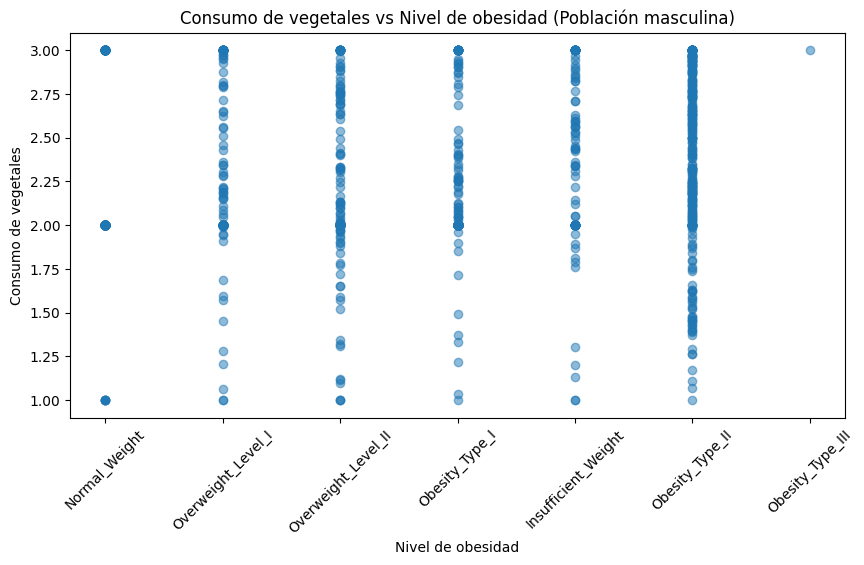

```python
# Codificar NivelDeObesidad a valores numéricos
import pandas as pd
import matplotlib.pyplot as plt

# Cargar datos
data = pd.read_csv("A1.1 Obesidad.csv")

# Filtrar subpoblación masculina
df = data[data["Sexo"] == "Male"].copy()

# Codificar NivelDeObesidad a valores numéricos
categorias = df["NivelDeObesidad"].unique()
mapa = {cat: i for i, cat in enumerate(categorias)}
df["NivelNum"] = df["NivelDeObesidad"].map(mapa)

# Gráfica de dispersión
plt.figure(figsize=(10, 5))
plt.scatter(
    x=df["NivelNum"],
    y=df["ComeVegetales"],
    alpha=0.5
)

# Etiquetas y títulos
plt.xticks(
    ticks=range(len(mapa)),
    labels=mapa.keys(),
    rotation=45
)
plt.xlabel("Nivel de obesidad")
plt.ylabel("Consumo de vegetales")
plt.title("Consumo de vegetales vs Nivel de obesidad (Población masculina)")
plt.show()
```

En conclusión, los resultados sugieren que, aunque el consumo de vegetales es un indicador importante de hábitos alimenticios saludables, no resulta suficiente por sí solo para explicar las diferencias en los niveles de obesidad dentro de la subpoblación analizada. Esto refuerza la idea de que la obesidad es un fenómeno multifactorial, influenciado por múltiples variables como la actividad física, otros hábitos alimenticios y factores de estilo de vida. El análisis realizado cumple con los objetivos planteados en la actividad y proporciona una base sólida para estudios inferenciales más profundos en trabajos futuros.